# Analysis of smart device usage data

Elena Koroleva

7 July 2021

## Business task

Analysis of trends in smart device usage data in order to improve the customer experience of Bellabeat users and adjust marketing strategy

## Datasource description

Public datasets available on Kaggle: https://www.kaggle.com/arashnic/fitbit/code

Licence: CC licensing

In our analysis we will work with following datasets:

- dailyActivity_merged.csv
- heartrate_seconds_merged.csv
- hourlyCalories_merged.csv
- hourlyIntensities_merged.cs
- hourlySteps_merged.csv
- sleepDay_merged.csv
- weightLogInfo_merged.csv

Other datasets are redundant and will not let us catch trends of smart device usage.

*In our analysis we will assume that data is not biased, which means that it was randomly generated and includes women of different age, country and body constitution*

## Data cleaning and organization

### 1. Import of libraries and files:

```r
library(hms)
library(plyr)
library(tidyverse)
library(skimr)
library(readr)
library(dplyr)
library(Rcpp)
library(lubridate)
library(PerformanceAnalytics)
daily_activ <- read.csv('/Users/korol/Documents/bellabeat/Activities_daily_20210708_bellabeat.csv')
heartrate <- read.csv('/Users/korol/Documents/bellabeat/Heartrate_20210708_bellabeat.csv')
calories <- read.csv('/Users/korol/Documents/bellabeat/Calories_hours_20210708_bellabeat.csv')
intensity <- read.csv('/Users/korol/Documents/bellabeat/Intensity_hours_20210708_bellabeat.csv')
steps <- read.csv('/Users/korol/Documents/bellabeat/Steps_hours_20210708_bellabeat.csv')
sleep <- read.csv('/Users/korol/Documents/bellabeat/Sleep_20210708_bellabeat.csv')
weight <- read.csv('/Users/korol/Documents/bellabeat/Weight_20210708_bellabeat.csv')
```

### 2. Data errors check

#### 2.1 Duplicate check:

```
## [1] "duplicates in data activity file 0"
```

```
## [1] "duplicates in data calories file 0"
```

```
## [1] "duplicates in data intensity file 0"
```

```
## [1] "duplicates in data steps file 0"
```

```
## [1] "duplicates in data sleep file 3"
```

```
## [1] "duplicates in data heartrate file 0"
```

```
## [1] "duplicates in data weight file 0"
```

According to the check, the dataset Sleep has 3 similar rows, which should be removed to avoid wrong conclusions.

#### 2.2 NA values check:

```
## [1] "NA values in data activity file 0"
```

```
## [1] "NA values in data calories file 0"
```

```
## [1] "NA values in data intensity file 0"
```

```
## [1] "NA values in data steps file 0"
```

```
## [1] "NA values in data sleep file 0"
```

```
## [1] "NA values in data heartrate file 0"
```

```
## [1] "NA values in data weight file 65"
```

The dataset Weight has a lot of NA values in one column, this column should be excluded from the analysis due to lack of information

#### 2.3 Number of unique values in each dataset:

```
## [1] "Number of unique values in data activity file 33"
```

```
## [1] "Number of unique values in data calories file 33"
```

```
## [1] "Number of unique values in data intensity file 33"
```

```
## [1] "Number of unique values in data steps file 33"
```

```
## [1] "Number of unique values in data sleep file 24"
```

```
## [1] "Number of unique values in data heartrate file 14"
```

```
## [1] "Number of unique values in data weight file 8"
```

Datasets have different number of entries, which give us an idea which one of them can be combined and which one should be analyzed separately

### 3. Work with data formats and transformation

#### 3.1 Weight dataset:

1. Overall view of the dataset:

```r
glimpse(weight)
```

```
## Rows: 67
## Columns: 8
## $ Id             <dbl> 1503960366, 1503960366, 1927972279, 2873212765, 2873212~
## $ Date           <chr> "5/2/2016 11:59:59 PM", "5/3/2016 11:59:59 PM", "4/13/2~
## $ WeightKg       <dbl> 52.6, 52.6, 133.5, 56.7, 57.3, 72.4, 72.3, 69.7, 70.3, ~
## $ WeightPounds   <dbl> 115.9631, 115.9631, 294.3171, 125.0021, 126.3249, 159.6~
## $ Fat            <int> 22, NA, NA, NA, NA, 25, NA, NA, NA, NA, NA, NA, NA, NA,~
## $ BMI            <dbl> 22.65, 22.65, 47.54, 21.45, 21.69, 27.45, 27.38, 27.25,~
## $ IsManualReport <chr> "True", "True", "False", "True", "True", "True", "True"~
## $ LogId          <dbl> 1.462234e+12, 1.462320e+12, 1.460510e+12, 1.461283e+12,~
```

2. Selecting the only columns with which we will work:

```r
weight_cut <- weight %>%
              distinct() %>%
              select(Id,Date, IsManualReport)
```

3. Working with data formats and dataset transformation:

```r
weight_final<-separate(weight_cut,Date, into =c('Date','Time','AM_PM'),sep=' ') %>%
              filter(IsManualReport == "False")

weight_final$Time <- as_hms(weight_final$Time)
```

#### 3.2 Calories, intensity and steps by hour datasets:

1. Overall view of the datasets:

```r
glimpse(calories)
```

```
## Rows: 22,099
## Columns: 3
## $ Id           <dbl> 1503960366, 1503960366, 1503960366, 1503960366, 150396036~
## $ ActivityHour <chr> "4/12/2016 12:00:00 AM", "4/12/2016 1:00:00 AM", "4/12/20~
## $ Calories     <int> 81, 61, 59, 47, 48, 48, 48, 47, 68, 141, 99, 76, 73, 66, ~
```

```r
glimpse(intensity)
```

```
## Rows: 22,099
## Columns: 4
## $ Id               <dbl> 1503960366, 1503960366, 1503960366, 1503960366, 15039~
## $ ActivityHour     <chr> "4/12/2016 12:00:00 AM", "4/12/2016 1:00:00 AM", "4/1~
## $ TotalIntensity   <int> 20, 8, 7, 0, 0, 0, 0, 0, 13, 30, 29, 12, 11, 6, 36, 5~
## $ AverageIntensity <dbl> 0.333333, 0.133333, 0.116667, 0.000000, 0.000000, 0.0~
```

```r
glimpse(steps)
```

```
## Rows: 22,099
## Columns: 3
## $ Id           <dbl> 1503960366, 1503960366, 1503960366, 1503960366, 150396036~
## $ ActivityHour <chr> "4/12/2016 12:00:00 AM", "4/12/2016 1:00:00 AM", "4/12/20~
## $ StepTotal    <int> 373, 160, 151, 0, 0, 0, 0, 0, 250, 1864, 676, 360, 253, 2~
```

2. Joining datasets in a single table:  
   All datasets have similar number of observations, which means they can be joined together

```r
x<-inner_join(calories, intensity, by = c("Id", "ActivityHour"))
Total_hours <-inner_join(x, steps, by = c("Id", "ActivityHour"))
```

3. Working with data formats and dataset transformation:

```r
Total_hours<-separate(Total_hours,ActivityHour, into =c('Date','Time'),sep=' ', extra = "merge")
Total_hours$Time <- format(strptime(Total_hours$Time, "%I:%M:%S %p"), "%H:%M:%S")
```

This transformation will help to determine dependencies between variables (calories, intensity, steps) and do an hour-by-hour analysis to identify patterns

#### Heart rate dataset:

1. Overall view of the dataset:

```r
glimpse(heartrate)
```

```
## Rows: 2,483,658
## Columns: 3
## $ Id    <dbl> 2022484408, 2022484408, 2022484408, 2022484408, 2022484408, 2022~
## $ Time  <chr> "4/12/2016 7:21:00 AM", "4/12/2016 7:21:05 AM", "4/12/2016 7:21:~
## $ Value <int> 97, 102, 105, 103, 101, 95, 91, 93, 94, 93, 92, 89, 83, 61, 60, ~
```

2. Working with data formats and dataset transformation:

```r
Heart<-separate(heartrate,Time, into =c('Date','Time'),sep=' ', extra = "merge")
Heart$Time <- format(strptime(Heart$Time, "%I:%M:%S %p"), "%H")
Heart<-Heart %>%
  mutate(WeekDay = wday(as.Date(Heart$Date, "%m/%d/%y"), label=TRUE) )
```

These transformations will allow us to prepare the dataset for future analysis of users routine (level of stress, hours of activity, etc.)

#### Sleep dataset:

1. Overall view of the dataset:

```r
glimpse(sleep)
```

```
## Rows: 413
## Columns: 5
## $ Id                 <dbl> 1503960366, 1503960366, 1503960366, 1503960366, 150~
## $ SleepDay           <chr> "4/12/2016 12:00:00 AM", "4/13/2016 12:00:00 AM", "~
## $ TotalSleepRecords  <int> 1, 2, 1, 2, 1, 1, 1, 1, 1, 1, 1, 1, 1, 1, 1, 1, 1, ~
## $ TotalMinutesAsleep <int> 327, 384, 412, 340, 700, 304, 360, 325, 361, 430, 2~
## $ TotalTimeInBed     <int> 346, 407, 442, 367, 712, 320, 377, 364, 384, 449, 3~
```

2. Working with data formats and dataset transformation:

```r
sleep <- sleep %>%
    distinct()

sleep <-sleep %>%
  mutate(WeekDay = wday(as.Date(sleep$SleepDay, "%m/%d/%y")-1, label=TRUE) ) %>%
  mutate(SleepTime = sleep$TotalMinutesAsleep/60)  %>%
  mutate(BedTime = sleep$TotalTimeInBed/60)
```

Converting time to hours and adding a week day will help to identify a users’ night routine

#### Activity dataset:

1. Overall view of the dataset:

```r
glimpse(daily_activ)
```

```
## Rows: 940
## Columns: 15
## $ Id                       <dbl> 1503960366, 1503960366, 1503960366, 150396036~
## $ ActivityDate             <chr> "4/12/2016", "4/13/2016", "4/14/2016", "4/15/~
## $ TotalSteps               <int> 13162, 10735, 10460, 9762, 12669, 9705, 13019~
## $ TotalDistance            <dbl> 8.50, 6.97, 6.74, 6.28, 8.16, 6.48, 8.59, 9.8~
## $ TrackerDistance          <dbl> 8.50, 6.97, 6.74, 6.28, 8.16, 6.48, 8.59, 9.8~
## $ LoggedActivitiesDistance <dbl> 0, 0, 0, 0, 0, 0, 0, 0, 0, 0, 0, 0, 0, 0, 0, ~
## $ VeryActiveDistance       <dbl> 1.88, 1.57, 2.44, 2.14, 2.71, 3.19, 3.25, 3.5~
## $ ModeratelyActiveDistance <dbl> 0.55, 0.69, 0.40, 1.26, 0.41, 0.78, 0.64, 1.3~
## $ LightActiveDistance      <dbl> 6.06, 4.71, 3.91, 2.83, 5.04, 2.51, 4.71, 5.0~
## $ SedentaryActiveDistance  <dbl> 0, 0, 0, 0, 0, 0, 0, 0, 0, 0, 0, 0, 0, 0, 0, ~
## $ VeryActiveMinutes        <int> 25, 21, 30, 29, 36, 38, 42, 50, 28, 19, 66, 4~
## $ FairlyActiveMinutes      <int> 13, 19, 11, 34, 10, 20, 16, 31, 12, 8, 27, 21~
## $ LightlyActiveMinutes     <int> 328, 217, 181, 209, 221, 164, 233, 264, 205, ~
## $ SedentaryMinutes         <int> 728, 776, 1218, 726, 773, 539, 1149, 775, 818~
## $ Calories                 <int> 1985, 1797, 1776, 1745, 1863, 1728, 1921, 203~
```

2. Working with data formats and dataset transformation:

```r
daily_activ <- daily_activ %>%
  mutate(WeekDay = wday(as.Date(daily_activ$ActivityDate, "%m/%d/%y"), label=TRUE))
```

This dataset will give a big picture of users’ behavior in terms of their activity. Transformation of the dataset will help us to identify patterns and improve user experience.

## Data analysis

#### Weight dataset:

1. Number of users tracking their weight in the app:

```r
print(n_distinct(weight_cut$Id))
```

```
## [1] 8
```

Out of 33 respondents only 8 (24%) of them created at least one entry of weight in the application. This leads us to the conclusion that this section of the application is not very popular. There may be several reasons for this:

- Users forget to enter data into the system
- It is not always convenient to do this, since it is not always possible to weigh yourself
- Users do not see practical value in this

Let’s dive deeper:

Around the users who insert data in the application, we identify the most convenient time of interaction with the application:

```r
weight_final<-weight_final %>%
  mutate(DayTime = case_when
         ((difftime(Time,as_hms("05:00:00") , units ='mins') >= 0) & (AM_PM == "AM") &
           (difftime(as_hms("09:00:00"), Time, units ='mins') >= 0) ~ 'Early morning'
          ,difftime(Time,as_hms("09:00:00") , units ='mins') > 0 & (AM_PM == "AM")
            & difftime(as_hms("12:00:00"), Time , units ='mins') > 0 ~ 'Late morning'
          ,difftime(Time,as_hms("04:00:00") , units ='mins') >=0 & (AM_PM == "PM") ~ 'Evening'
          ,(AM_PM == "PM") & difftime(as_hms("04:00:00"), Time , units ='mins') > 0 ~ 'Afternoon'
          ,TRUE ~ 'Night'))
```

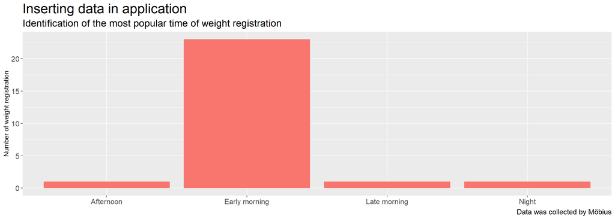

```r
ggplot(data=weight_final)+geom_bar(mapping = aes(x = DayTime, fill = "#FF6666"))+
       labs(title = "Inserting data in application",subtitle = "Identification of the most popular time of weight registration", caption = "Data was collected by Möbius")+
       ylab("Number of weight registration")+
        theme(legend.position = "none",axis.title.x = element_blank(),axis.text=element_text(size=12),plot.title = element_text(size=22), plot.subtitle = element_text(size=16), plot.caption = element_text(size=12))
```

As we can see the most popular time of weight registration in the application is early morning. Thus, a creation of an alert in the early morning time can positively affect user experience as far as now they will not forget about inserting the weight in the system, plus it is convenient for the majority of people, because in the early morning they are still at home.  
For the explanation of practical value the advice-notifications can be created. For example:

- People with overweight problem: tracking progress advices + motivation advices
- Average person: maintain a healthy lifestyle (weight control) advices
- Sportsmens: preparation for competitions (weight management), regime tracking advices

#### Calories, intensity and steps by hour datasets:

This dataset will give us a close look to the users’ day routine.

Data aggregation (calories, intensity and steps) by hour:

```r
Aggr_hours <- Total_hours %>%
              group_by(Time) %>%
              summarise(mean_calories=mean(Calories),mean_steps= mean(StepTotal), mean_intensity=mean(TotalIntensity))
```

Graphical representation of findings:

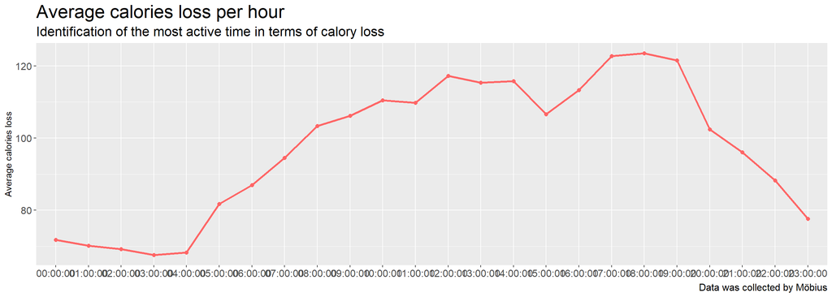

```r
ggplot(Aggr_hours, aes(x=Time, y=mean_calories, group=1)) + geom_line(size=1.2, color ="#FF6666")+geom_point(size=2,color ="#FF6666")+
  labs(title = "Average calories loss per hour",subtitle = "Identification of the most active time in terms of calory loss", caption = "Data was collected by Möbius")+
  ylab("Average calories loss")+
    theme(legend.position = "none",axis.title.x = element_blank(),axis.text=element_text(size=12),plot.title = element_text(size=22), plot.subtitle = element_text(size=16), plot.caption = element_text(size=12))
```

As we can see the peaks of activity occur from 12-14 and from 17-19: lunch break and the end of the work day. At the same time, it is worths to mention that level of activity starts to grow from 5:00 and drops after 19:00.

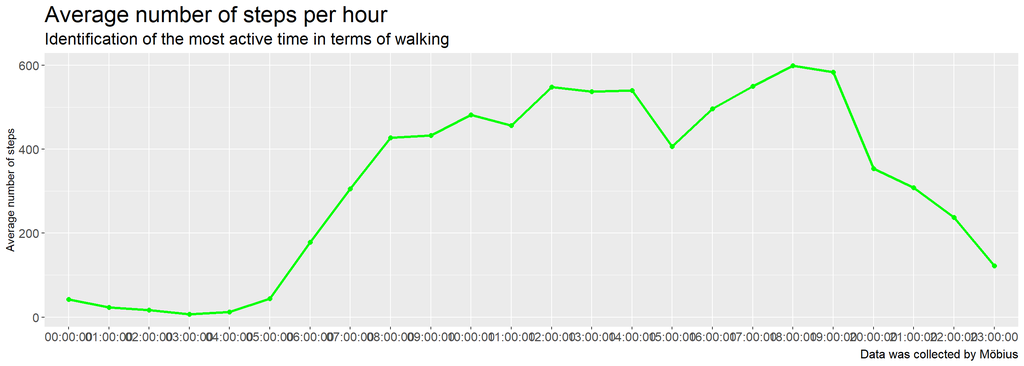

```r
ggplot(Aggr_hours, aes(x=Time, y=mean_steps, group=1)) + geom_line(size=1.2, color ="green")+geom_point(size=2,color ="green")+
  labs(title = "Average number of steps per hour",subtitle = "Identification of the most active time in terms of walking", caption = "Data was collected by Möbius")+
  ylab("Average number of steps")+
    theme(legend.position = "none",axis.title.x = element_blank(),axis.text=element_text(size=12),plot.title = element_text(size=22), plot.subtitle = element_text(size=16), plot.caption = element_text(size=12))
```

The dynamic of average steps has a similar tendency as calory loss, which give us an idea about the correlation between these two variables. However, we observed that calory loss is at a consistently high level from 17 to 18, but the number of steps is showing the growth. This means that calory loss does not depend only on number of steps

To dive a bit deeper into the topic, I analyzed the intensity of exercises as well:

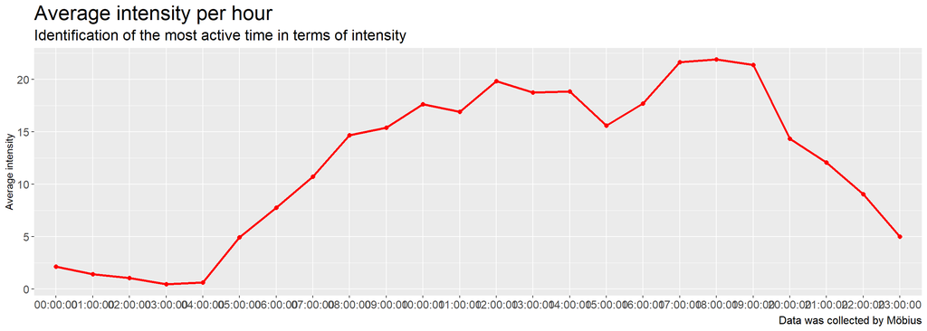

```r
ggplot(Aggr_hours, aes(x=Time, y=mean_intensity, group=1)) + geom_line(size=1.2, color ="red")+geom_point(size=2, color ="red")+
  labs(title = "Average intensity per hour",subtitle = "Identification of the most active time in terms of intensity", caption = "Data was collected by Möbius")+
  ylab("Average intensity")+
    theme(legend.position = "none",axis.title.x = element_blank(),axis.text=element_text(size=12),plot.title = element_text(size=22), plot.subtitle = element_text(size=16), plot.caption = element_text(size=12))
```

Intensity shows quite similar dynamic as the calory loss. This leads us to the conclusion that there is a correlation between these two variables.

Checking the correlation between factors:

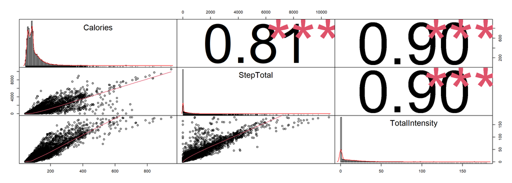

```r
Total_hours_cut <- Total_hours %>%
  distinct() %>%
  select(Calories,StepTotal, TotalIntensity)

chart.Correlation(Total_hours_cut, histogram=TRUE, pch=19)
```

We can notice very strong dependencies between calories and steps, calories and intensity.

Thus, we identified that:

- There is a strong correlation between calories and steps, calories and intensity, intensity and steps. This can help us to improve our membership programs and advice section by proposing different types of activities: intensive, intermediate (walking activities) and combination of intensive exercises and walking
- Communication with the user about physical activities should be when he is in an active phase: from 5:00 and drops after 19:00
- Company could think about the product combination: as we can see people are mostly doing intense exercises in the lunch time and after work, adding the recommendation using a product “Spring” (smart bottle) can help users to avoid dehydration

#### Activity dataset:

This dataset will help us to get a bigger picture about users routine and activities.

First we will check the overall dynamic of calories loss and steps made.

```r
aggr_week_cal <- daily_activ %>%
  distinct() %>%
  group_by(WeekDay) %>%
  summarise(mean_calories=mean(Calories),mean_steps=mean(TotalSteps))
```

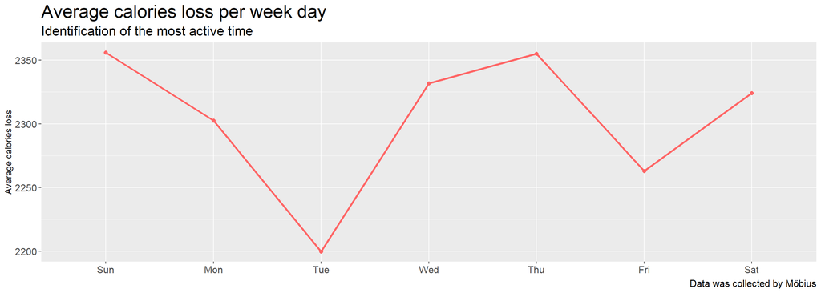

```r
ggplot(aggr_week_cal,aes(x= WeekDay,group =1))+
  geom_line(aes(y = mean_calories),  size=1.2,color ="#FF6666") +geom_point(aes(y = mean_calories),size=2,color ="#FF6666") +
  labs(title = "Average calories loss per week day",subtitle = "Identification of the most active time", caption = "Data was collected by Möbius")+
  ylab("Average calories loss")+
  theme(legend.position = "none",axis.title.x = element_blank(),axis.text=element_text(size=12),plot.title = element_text(size=22), plot.subtitle = element_text(size=16), plot.caption = element_text(size=12))
```

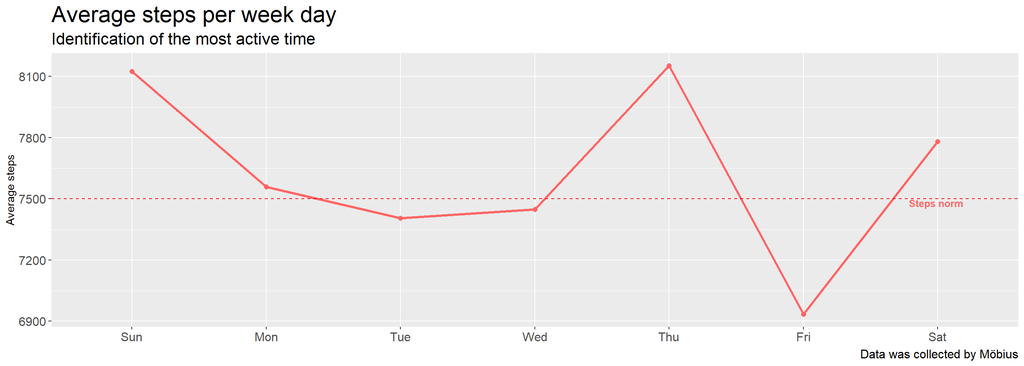

```r
ggplot(aggr_week_cal,aes(x= WeekDay,group =1))+
  geom_line(aes(y = mean_steps),  size=1.2,color ="#FF6666") +geom_point(aes(y = mean_steps),size=2,color ="#FF6666") +
  geom_hline(yintercept=7500,color="red",linetype="dashed") +
  labs(title = "Average steps per week day",subtitle = "Identification of the most active time", caption = "Data was collected by Möbius")+
  ylab("Average steps")+
  theme(legend.position = "none",axis.title.x = element_blank(),axis.text=element_text(size=12),plot.title = element_text(size=22), plot.subtitle = element_text(size=16), plot.caption = element_text(size=12)) +
  annotate("text",x=6.99,y=7480, label="Steps norm", color = "#FF6666", fontface ="bold",size =3.4)
```

As we can notice from the graph not always people perform the steps norm [Link](https://www.health.harvard.edu/blog/10000-steps-a-day-or-fewer-2019071117305). If we will look at the average number of steps, we will see that there is a correlation between the calories loss and number of steps made, which is obvious. However, there are some differences like, for example, Tuesday and Monday. Clearly there are other factors affecting calories loss.

One of them can be the activity level:

```r
aggr_week_activ_total_min <- daily_activ %>%
  distinct() %>%
  group_by(WeekDay) %>%
  summarise(Sedentary=mean(SedentaryMinutes)/60,Light=mean(LightlyActiveMinutes)/60, Fairly = mean(FairlyActiveMinutes)/60,Very_active = mean(VeryActiveMinutes)/60)
```

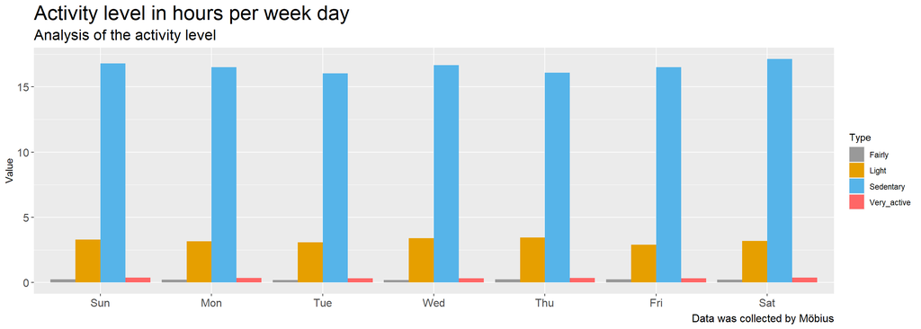

```r
aggr_week_activ_total_min %>%
  gather("Type", "Value",-WeekDay) %>%
  ggplot(aes(WeekDay, Value, fill = Type)) +
  geom_bar(position = "dodge", stat = "identity") +
  scale_fill_manual(values=c("#999999", "#E69F00", "#56B4E9","#FF6666")) +
  labs(title = "Activity level in hours per week day",subtitle = "Analysis of the activity level", caption = "Data was collected by Möbius") +
  theme(axis.title.x = element_blank(),axis.text=element_text(size=12),plot.title = element_text(size=22), plot.subtitle = element_text(size=16),    plot.caption = element_text(size=12))
```

As we can see on the graph, most part of time people spend sitting (Sedentary minutes), which of course can have a negative effect on the health if person does not do sport and follow nutrition advices.

However, we will need to dive deeper in order to see better the split between active, fairly active and light active time:

```r
aggr_week_activ_min <- daily_activ %>%
  distinct() %>%
  group_by(WeekDay) %>%
  summarise(Light=mean(LightlyActiveMinutes), Fairly = mean(FairlyActiveMinutes),Very_active = mean(VeryActiveMinutes))
```

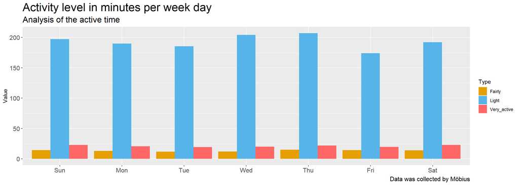

```r
aggr_week_activ_min %>%
  gather("Type", "Value",-WeekDay) %>%
  ggplot(aes(WeekDay, Value, fill = Type)) +
  geom_bar(position = "dodge", stat = "identity") +
  scale_fill_manual(values=c("#E69F00", "#56B4E9","#FF6666")) +
  labs(title = "Activity level in minutes per week day",subtitle = "Analysis of the active time", caption = "Data was collected by Möbius")+
    theme(axis.title.x = element_blank(),axis.text=element_text(size=12),plot.title = element_text(size=22), plot.subtitle = element_text(size=16),    plot.caption = element_text(size=12))
```

Now we can check how all these factors affect calories loss:

```r
model <- lm(daily_activ$Calories ~ daily_activ$LightlyActiveMinutes + daily_activ$FairlyActiveMinutes + daily_activ$VeryActiveMinutes + daily_activ$TotalDistance, data = daily_activ)
summary(model)
```

```
##
## Call:
## lm(formula = daily_activ$Calories ~ daily_activ$LightlyActiveMinutes +
##     daily_activ$FairlyActiveMinutes + daily_activ$VeryActiveMinutes +
##     daily_activ$TotalDistance, data = daily_activ)
##
## Residuals:
##      Min       1Q   Median       3Q      Max
## -2361.05  -324.24   -44.24   396.12  2040.26
##
## Coefficients:
##                                   Estimate Std. Error t value Pr(>|t|)
## (Intercept)                      1669.3050    36.0132  46.353  < 2e-16 ***
## daily_activ$LightlyActiveMinutes    0.6217     0.2084   2.983  0.00293 **
## daily_activ$FairlyActiveMinutes     0.3989     0.9661   0.413  0.67979
## daily_activ$VeryActiveMinutes       8.3571     0.8049  10.383  < 2e-16 ***
## daily_activ$TotalDistance          60.5023     8.3945   7.207 1.18e-12 ***
## ---
## Signif. codes:  0 '***' 0.001 '**' 0.01 '*' 0.05 '.' 0.1 ' ' 1
##
## Residual standard error: 519.5 on 935 degrees of freedom
## Multiple R-squared:  0.479,  Adjusted R-squared:  0.4768
## F-statistic: 214.9 on 4 and 935 DF,  p-value: < 2.2e-16
```

All factors besides Fairly active minutes were found to be significant, which means they have a direct impact on calorie loss. At the same time, distance and very active minutes have the biggest impact.

#### Heart rate dataset:

This dataset will help us to understand more users’ lifestyle based on the heart rate data.

Hour-by-hour analysis:

```r
Aggr_hours_heart <- Heart %>%
  group_by(Time) %>%
  summarise(mean_rate=mean(Value))
```

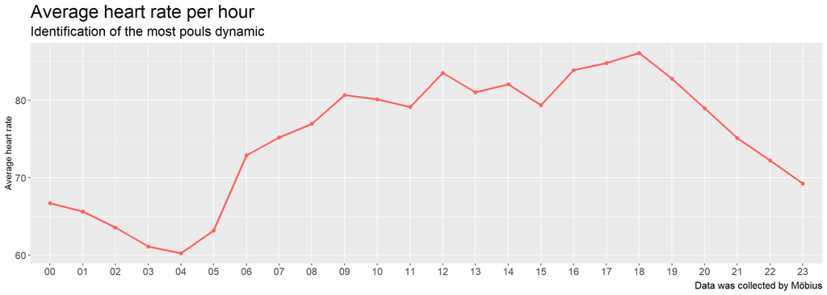

```r
ggplot(Aggr_hours_heart, aes(x=Time, y=mean_rate, group=1)) + geom_line(size=1.2, color ="#FF6666")+geom_point(size=2, color ="#FF6666")+
  labs(title = "Average heart rate per hour",subtitle = "Identification of the most pouls dynamic", caption = "Data was collected by Möbius")+
  ylab("Average heart rate")+
    theme(legend.position = "none",axis.title.x = element_blank(),axis.text=element_text(size=12),plot.title = element_text(size=22), plot.subtitle = element_text(size=16), plot.caption = element_text(size=12))
```

In general, during the day heart rate is at 80 beats per minute (which is still under the norm [Link](https://www.e-sante.fr/pouls-et-rythme-cardiaque-les-valeurs-normales/actualite/615242)). After 18:00 as we can see the rhythm of heart is slowing down, which gives us an idea about the returning in the calm state.

Looking at the problem from the higher level:

```r
Aggr_week_heart <- Heart %>%
  group_by(WeekDay) %>%
  summarise(mean_rate=mean(Value))
```

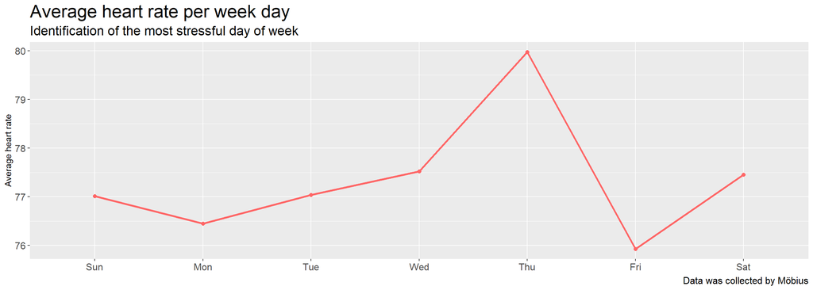

```r
ggplot(Aggr_week_heart, aes(x=WeekDay, y=mean_rate, group=1)) + geom_line(size=1.2, color ="#FF6666")+geom_point(size=2, color ="#FF6666")+
  labs(title = "Average heart rate per week day",subtitle = "Identification of the most stressful day of week", caption = "Data was collected by Möbius")+
  ylab("Average heart rate")+
  theme(legend.position = "none",axis.title.x = element_blank(),axis.text=element_text(size=12),plot.title = element_text(size=22), plot.subtitle = element_text(size=16), plot.caption = element_text(size=12))
```

This shows us a very interesting result. According to the graph the highest heart rate is observed on Thursday and the lowest on Friday. The result can be explained by the end of the work week: on Thursday we are usually tired and trying to finalize all the tasks before the end of the week. Friday is more relaxed day, people already think about the weekend, pause from the work, etc.

Thus, we can make the following conlcusions:

- The highest heart rate is observed on Thursdays, at the end of work day. This information can be taken into consideration for improvement of proposed activities in Bellabeat membership
- Company can propose their members’ activities to reduce level of stress: meditation, yoga, etc.
- To prevent the risk of increased heart rate smart watch and/or the app can anticipate and recommend to take a small break, make a breathing exercises, etc. before the stressful hour

#### Sleep dataset:

Sleep is one of the most important components of a healthy lifestyle. This dataset will allow us to identify how the smart devices can improve the user’s life.

As a first step we will aggregate data and check how much time people sleep and how it depends on the day of the week.

```r
Aggr_week_sleep <- sleep %>%
  group_by(WeekDay) %>%
  summarise(mean_sleep=mean(SleepTime),mean_bed=mean(BedTime))
```

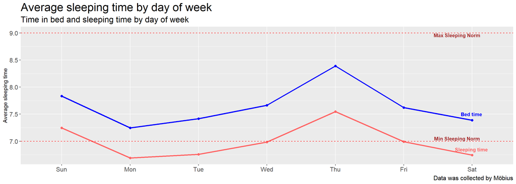

```r
ggplot(Aggr_week_sleep, aes(x=WeekDay,group=1)) +
  geom_line(aes(y = mean_sleep),  size=1.2,color ="#FF6666") +geom_point(aes(y = mean_sleep),size=2,color ="#FF6666") +
  geom_line(aes(y = mean_bed), size=1.2,color ="blue" ) +geom_point(aes(y = mean_bed),size=2,color ="blue")+
  geom_hline(yintercept=7,color="red",linetype="dashed") +
  geom_hline(yintercept=9,color="red",linetype="dashed") +
  labs(title = "Average sleeping time by day of week",subtitle = "Time in bed and sleeping time by day of week", caption = "Data was collected by Möbius")+
  ylab("Average sleeping time") +
  annotate("text",x=6.78,y=8.96, label="Max Sleeping Norm", color = "brown", fontface ="bold",size =3.4)+
  annotate("text",x=6.78,y=7.05, label="Min Sleeping Norm", color = "brown", fontface ="bold",size =3.4) +
  annotate("text",x=6.99,y=7.5, label="Bed time", color = "blue", fontface ="bold",size =3.4) +
  annotate("text",x=6.99,y=6.85, label="Sleeping time", color = "#FF6666", fontface ="bold",size =3.4) +
  theme(legend.position = "none",axis.title.x = element_blank(),axis.text=element_text(size=12),plot.title = element_text(size=22), plot.subtitle = element_text(size=16), plot.caption = element_text(size=12))
```

Thus, we can conclude:

- Users do not sleep enough, which can after affect their health. The alerts, linked to the alarm time, with recommendations to start to prepare for the sleeping time can help them to optimize their time and plan the evening better
- At the same, it is clear that Moday and Tuesday are very hard to users as far as they should adapt each time to the working hours after the weekend. The solution can be an integration in the application relaxing music or reading of audiobooks in order make the users fall asleep faster.

## Recommendations

1. Specific attention and work on the weight section:
   - Attract attention to this section by creating of morning alerts. Bellabeat app should become a part of morning routine
   - Advice notifications integration: small messages with advices how to better organize the day, track and control weight, etc. based on the user profile: overweighted, average, sportsman to increase the number of iterations with the app
   - Increase the motivation of users by creating a supporting community, so users can share their progress, discuss how to manage weight problems, etc.
2. Improvement of existing training programs and communications with users based on their active time:
   - According to the research training programs and advices can be built based on active level and walking distance: adaptation to the user lifestyle and need
   - Prevention of dramatic increase and loss of calories by keeping users on the average activity level with notifications
   - Proposition of new routes to reach work, shop, school, etc. in order to adjust the number of steps per day
   - Suggestion of the small training programs (light activity level), which can be performed even at work place in order to decrease the level of sedentary activities
3. Work on the stress reduce section:
   - Heart rate is changing depending on the day of the week and time, which can be used to make the application services wide
   - To anticipate and not allow the increase of heart rate application can have the section with calming activities: breathing exercises, meditation, etc.
4. Development of sleeping section of the app:
   - Analysis showed that the majority of users cannot fall asleep fast. They spend around one hour without sleep in the bed
   - To help users fight insomnia application can have an automatic alerts connected to the alarm and notify users when it is time to prepare to sleep. This notification can also help to make the process of waking up more pleasant, calculating when to fall asleep so that the alarm clock does not ring during the deep phase of sleep
   - Adding in application audiobooks and calming music can positively affect the sleeping process by reducing the time person spends on the phone.